# Indicadores g5

Viviane Serra Melanda, Humberto Cereser Ibanez, Cláudia Sirlene de Oliveira e [Henrique Laureano](https://henriquelaureano.github.io/)

Last modification on* 2022-05-20 10:33:22

> File: *anomalia_neoplasia_14a18_agrotoxico_14a18_mai22.xlsx*

# Indicadores

Medidas descritivas

| agr | Mínimo | 1o Quartil | Mediana | Média | 3o Quartil | Máximo | Desvio Padrão |
| --- | --- | --- | --- | --- | --- | --- | --- |
| menor_ld | 0 | 0.0 | 0 | 6.68 | 0.0 | 609 | 38.13 |
| menor_lq | 0 | 27.5 | 45 | 65.79 | 85.5 | 590 | 70.32 |
| menor_vmp | 0 | 0.0 | 0 | 4.91 | 4.0 | 210 | 15.08 |
| maigu_vmp | 0 | 0.0 | 0 | 2.38 | 0.0 | 57 | 6.23 |

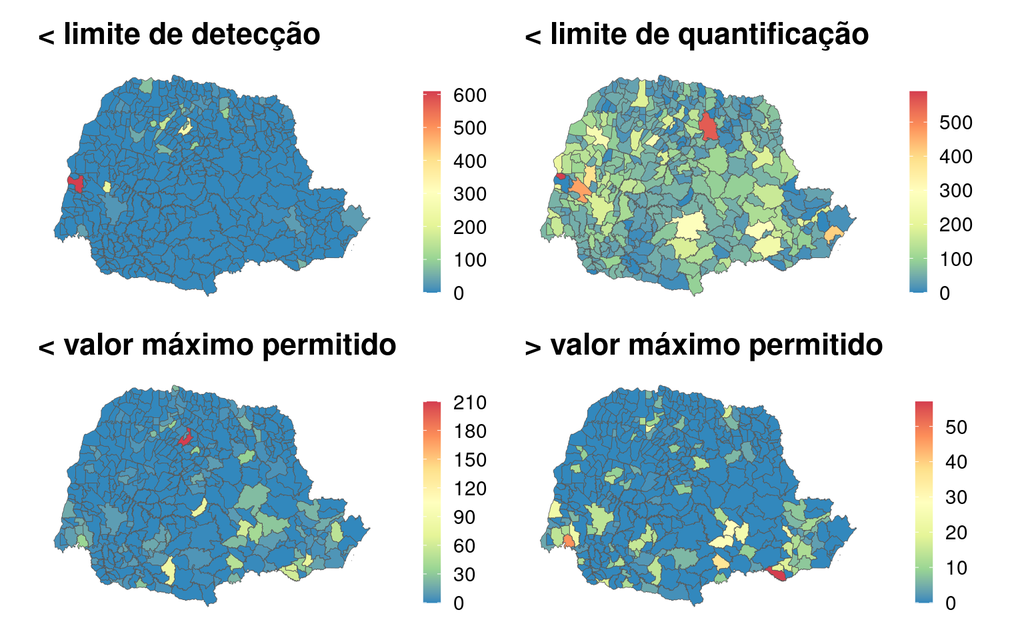

| var | Moran I statistic | Expectation | Variance | p-value |
| --- | --- | --- | --- | --- |
| menor_ld | 0.0110367 | -0.0025126 | 0.0005701 | 0.5703832 |
| menor_lq | 0.1101343 | -0.0025126 | 0.0009257 | 0.0002136 |
| menor_vmp | 0.0634899 | -0.0025126 | 0.0007488 | 0.0158618 |
| maigu_vmp | 0.1443155 | -0.0025126 | 0.0009084 | 0.0000011 |

> Com o **teste de Moran** verificamos se existe efeito/correlação espacial. Estatísticas maiores que o valor esperado indicam correlação espacial positiva. Valores menores indicam correlação negativa.

> Em vermelho, tudo que for significativo no nível de 5%.

Medidas descritivas

| type | Mínimo | 1o Quartil | Mediana | Média | 3o Quartil | Máximo | Desvio Padrão |
| --- | --- | --- | --- | --- | --- | --- | --- |
| indic1 | 0 | 0.00 | 0.00 | 0.12 | 0.14 | 1 | 0.21 |
| indic2 | 0 | 0.41 | 0.41 | 0.44 | 0.46 | 1 | 0.15 |
| indic3 | 0 | 0.50 | 0.54 | 0.53 | 0.57 | 1 | 0.09 |
| mediana | 0 | 0.44 | 0.47 | 0.47 | 0.50 | 1 | 0.09 |
| media | 0 | 0.38 | 0.41 | 0.41 | 0.44 | 1 | 0.09 |

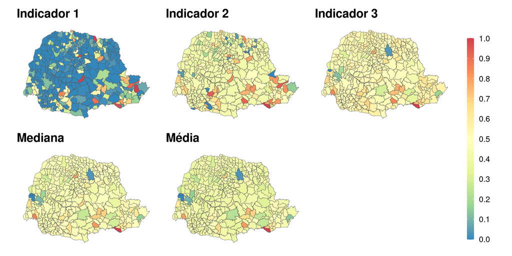

| var | Moran I statistic | Expectation | Variance | p-value |
| --- | --- | --- | --- | --- |
| indic1 | 0.1487953 | -0.002512563 | 0.0009584407 | 0.0000010217 |
| indic2 | 0.1269759 | -0.002512563 | 0.0009628145 | 0.0000300469 |
| indic3 | 0.1112206 | -0.002512563 | 0.0009449528 | 0.0002157407 |
| mediana | 0.1743485 | -0.002512563 | 0.0009464284 | 0.0000000090 |
| média | 0.1747601 | -0.002512563 | 0.0009468492 | 0.0000000084 |

# Modelagem SIH

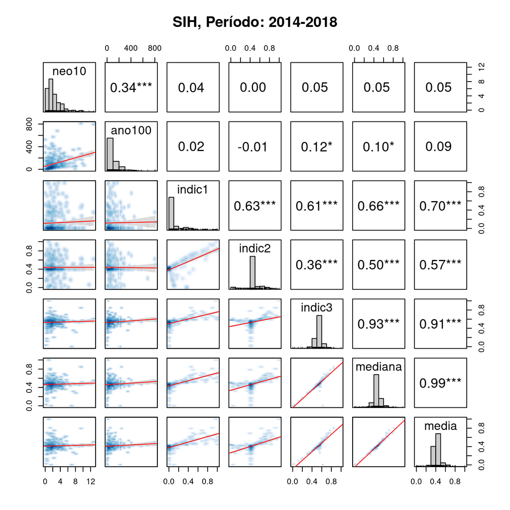

# References

> The main `R` (R Core Team, 2022) packages used in this analysis were: {`dplyr`} (Wickham et al., 2022), {`stringr`} (Wickham, 2019), {`tidyr`} (Wickham and Girlich, 2022), {`haven`} (Wickham et al., 2022), {`purrr`} (Henry and Wickham, 2020), {`ggplot2`} (Wickham, 2016), {`psych`} (Revelle, 2021), {`geobr`} (Pereira and Gancalves, 2022), {`patchwork`} (Pedersen, 2020), {`spdep`} (Bivand et al., 2013; Bivand, 2022), and {`psych`} (Revelle, 2022),

> R Core Team (2022). R: A language and environment for statistical computing. R Foundation for Statistical Computing, Vienna, Austria. URL https://www.R-project.org/

> Wickham, H., François, R., Henry, L., Müller, K. (2022). dplyr: A Grammar of Data Manipulation. R package version 1.0.9. https://CRAN.R-project.org/package=dplyr

> Wickham, H., Girlich, M. (2022). tidyr: Tidy Messy Data. R package version 1.2.0. https://CRAN.R-project.org/package=tidyr

> Wickham, H. (2019). stringr: Simple, Consistent Wrappers for Common String Operations. R package version 1.4.0. https://CRAN.R-project.org/package=stringr

> Wickham. H., Miller, E., Smith, D. (2022). haven: Import and Export ‘SPSS’, ‘Stata’ and ‘SAS’ Files. R package version 2.5.0. https://CRAN.R-project.org/package=haven

> Henry, L., Wickham, H. (2020). purrr: Functional Programming Tools. R package version 0.3.4. https://CRAN.R-project.org/package=purrr

> Wickham, H. (2016). ggplot2: Elegant Graphics for Data Analysis. Springer-Verlag New York

> Pedersen, T. L. (2020). patchwork: The Composer of Plots. R package version 1.1.1, https://CRAN.R-project.org/package=patchwork

> Revelle, W. (2022). psych: Procedures for Personality and Psychological Research, Northwestern University, Evanston, Illinois, USA, R package version 2.2.3. https://CRAN.R-project.org/package=psych

> Pereira, R. H. M., Goncalves, C. N. (2022). geobr: Download Official Spatial Data Sets of Brazil. R package version 1.6.5999. https://github.com/ipeaGIT/geobr

> Bivand, R. S., Pebesma, Gomez-Rubio, V. (2013). Applied spatial data analysis with R, Second edition. Springer, NY. https://asdar-book.org/

> Bivand, R. S. (2022). R Packages for Analyzing Spatial Data: A Comparative Case Study with Areal Data Geographical Analysis https://doi.org/10.1111/gean.12319